# HW 3

Student Name

9/24/2024

# 1

Let $E[X] = \mu$. Show that $Var[X] := E[(X-E[X])^2] = E[X^2]-(E[X])^2$. Note, all you have to do is show the second equality (the first is our definition from class).

$Var[X] := E[(X-E[X])^2] = E[X^2-2X*E[X]+(E[X])^2] = E[X^2] - 2*E[X]*E[X] + (E[X])^2 = E[X^2] - (E[X])^2$

# 2

In the computational section of this homework, we will discuss support vector machines and tree-based methods. I will begin by simulating some data for you to use with SVM.

```r
library(e1071)
```

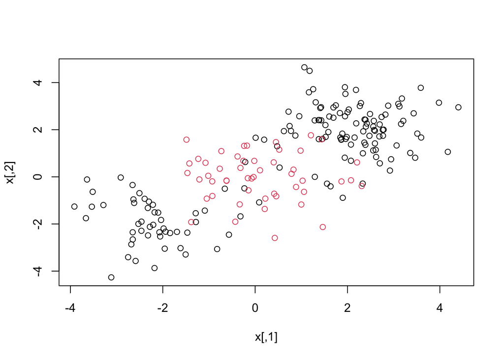

```r
set.seed(1)
x=matrix(rnorm(200*2),ncol=2)
x[1:100,]=x[1:100,]+2
x[101:150,]=x[101:150,]-2
y=c(rep(1,150),rep(2,50))
dat=data.frame(x=x,y=as.factor(y))
plot(x, col=y)
```

## 2.1

Quite clearly, the above data is not linearly separable. Create a training-testing partition with 100 random observations in the training partition. Fit an svm on this training data using the radial kernel, and tuning parameters $\gamma=1$, cost $=1$. Plot the svm on the training data.

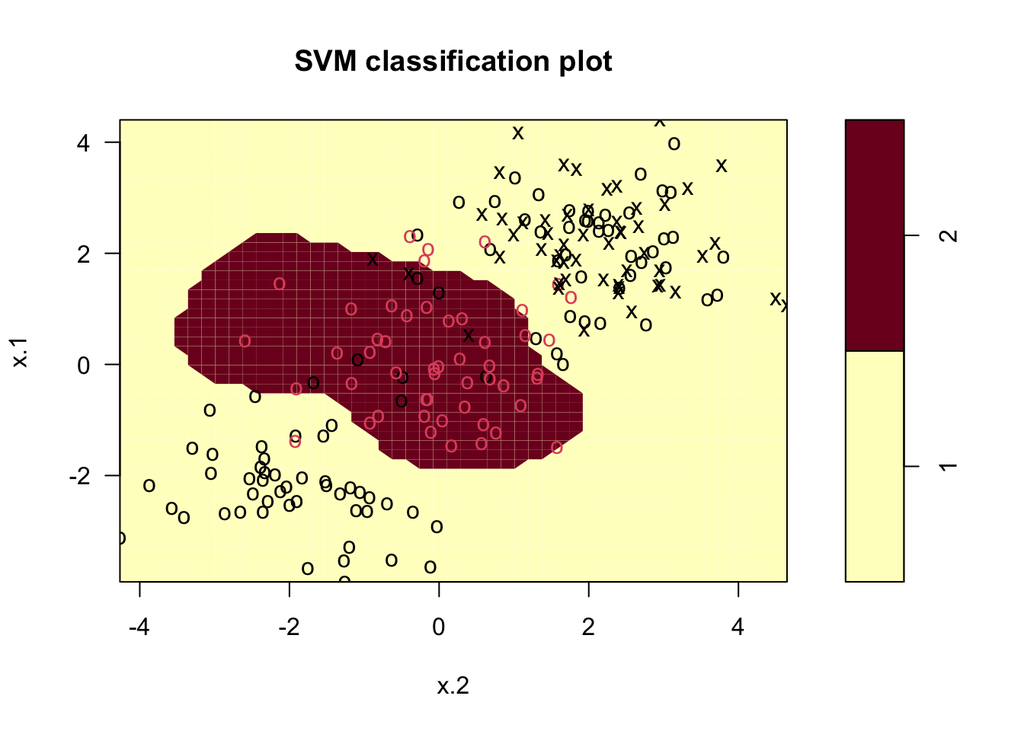

```r
set.seed(1)
train =  sample(1:nrow(dat), 100)
dat_train = dat[train,]
dat_test = dat[-train,]
svmfit = svm(y ~ ., data = dat_train, kernel = "radial", cost = 1, scale = FALSE, gamma = 1)

plot(svmfit, dat)
```

## 2.2

Notice that the above decision boundary is decidedly non-linear. It seems to perform reasonably well, but there are indeed some misclassifications. Let’s see if increasing the cost [^1] helps our classification error rate. Refit the svm with the radial kernel, $\gamma=1$, and a cost of 10000. Plot this svm on the training data.

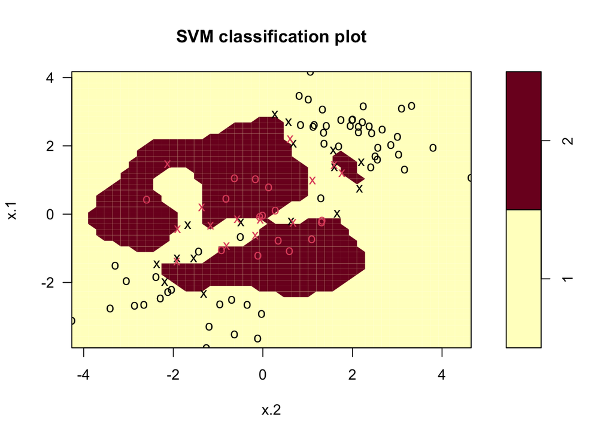

```r
svmfit = svm(y ~ ., data = dat_train, kernel = "radial", cost = 10000, scale = FALSE, gamma = 1)

plot(svmfit, dat_train)
```

## 2.3

It would appear that we are better capturing the training data, but comment on the dangers (if any exist), of such a model.

This is an extremely overfit model which could lead to poor predictions on test data.

## 2.4

Create a confusion matrix by using this svm to predict on the current testing partition. Comment on the confusion matrix. Is there any disparity in our classification results?

```r
#remove eval = FALSE in above
table(true=dat[-train,"y"], pred=predict(svmfit, newdata=dat[-train,]))
```

```
##     pred
## true  1  2
##    1 62 17
##    2  3 18
```

## 2.5

Is this disparity because of imbalance in the training/testing partition? Find the proportion of class `2` in your training partition and see if it is broadly representative of the underlying 25% of class 2 in the data as a whole.

```r
nrow(dat_train[y=="2",])/nrow(dat_train)
```

```
## [1] 0.5
```

## 2.6

Let’s try and balance the above to solutions via cross-validation. Using the `tune` function, pass in the training data, and a list of the following cost and $\gamma$ values: {0.1, 1, 10, 100, 1000} and {0.5, 1,2,3,4}. Save the output of this function in a variable called `tune.out`.

```r
set.seed(1)
tune.out = tune(svm, y ~ ., data = dat_train, ranges = list(cost = c(0.1, 1, 10, 100, 1000), gamma = c(.5, 1, 2, 3, 4)))
```

I will take `tune.out` and use the best model according to error rate to test on our data. I will report a confusion matrix corresponding to the 100 predictions.

```r
table(true=dat[-train,"y"], pred=predict(tune.out$best.model, newdata=dat[-train,]))
```

[output not shown]

## 2.7

Comment on the confusion matrix. How have we improved upon the model in question 2 and what qualifications are still necessary for this improved model.

```r
library(kmed)
data(heart)
library(tree)
```

## 2.8

The response variable is currently a categorical variable with four levels. Convert heart disease into binary categorical variable. Then, ensure that it is properly stored as a factor.

```r
classfac = as.factor(as.numeric(heart$class > 0))
heart$classfac = classfac
```